# Prediction intervals for GLMs

# Overview

Our implementation of prediction intervals (when `simulate_pi` = FALSE) follows that described by Gavin Simpson in two posts on his [blog](https://fromthebottomoftheheap.net). Whilst what follows is a brief overview, more detail, including discussion on whether or not it makes sense to calculate these intervals, can be found in the following [post](https://fromthebottomoftheheap.net/2017/05/01/glm-prediction-intervals-i/).

## Confidence interval

To calculate prediction intervals we first calculate the confidence interval on the scale of the linear predictor. The upper and lower bounds of this interval, are then fed in to the inverse link function which in turn gives us a confidence interval on the expected response.

## Prediction interval

Once we have calculated the confidence interval on the response we feed the upper and lower bounds, in to the quantile function associated with the relevant distribution. The maximum and minimum values of the output are then used as the upper and lower bounds of our prediction interval.

# Comparison to a bootstrap approach

Below we compare the prediction intervals from trending with those generated by the ciTools package. ciTools uses a parametric bootstrap approach so the expectation is that **trending** will produce a more conservative (wider) interval when we allow for uncertainty around the estimate, and a less conservative (narrower) interval when uncertainty is ignored.

The following examples build on those discussed in the [ciTools glm vignette](https://CRAN.R-project.org/package=ciTools/vignettes/ciTools-glm-vignette.html):

## setup

```r
library(ciTools)
library(trending)
library(ggplot2)
library(patchwork)
library(MASS)
```

## Example 1 - Poisson

```r
# generate data
x <- rnorm(100, mean = 0)
y <- rpois(n = 100, lambda = exp(1.5 + 0.5*x))
dat <- data.frame(x = x, y = y)
fit <- glm(y ~ x , family = poisson(link = "log"))

# use ciTools to add prediction interval
dat1 <- add_pi(dat, fit, names = c("lpb", "upb"), alpha = 0.1, nsims = 20000)
head(dat1)
```

```
#>            x  y     pred lpb upb
#> 1 -1.7051837  2 1.978464   0   5
#> 2 -0.7533523  3 3.232369   1   6
#> 3  0.4280385  9 5.944711   2  10
#> 4 -0.1654847  2 4.377160   1   8
#> 5  0.4824726  4 6.113966   2  11
#> 6  0.9575575 12 7.811480   4  13
```

```r
# add intervals with trending (no uncertainty in parameters)
poisson_model <- glm_model(y ~ x, family = "poisson")
fitted_model <- fit(poisson_model, dat)
dat2 <- predict(fitted_model, simulate_pi = FALSE, uncertain = FALSE, alpha = 0.1)
dat2 <- get_result(dat2)
head(dat2[[1]])
```

```
#> <trending_prediction> 6 x 7
#>       y      x estimate lower_ci upper_ci lower_pi upper_pi
#>   <int>  <dbl>    <dbl>    <dbl>    <dbl>    <dbl>    <dbl>
#> 1     2 -1.71      1.98     1.66     2.36        0        5
#> 2     3 -0.753     3.23     2.88     3.63        1        6
#> 3     9  0.428     5.94     5.54     6.38        2       10
#> 4     2 -0.165     4.38     4.01     4.77        1        8
#> 5     4  0.482     6.11     5.70     6.56        2       10
#> 6    12  0.958     7.81     7.24     8.43        4       13
```

```r
# add intervals with trending (uncertainty in parameters)
dat3 <- predict(fitted_model, simulate_pi = FALSE, alpha = 0.1)
dat3 <- get_result(dat3)
head(dat3[[1]])
```

```
#> <trending_prediction> 6 x 7
#>       y      x estimate lower_ci upper_ci lower_pi upper_pi
#>   <int>  <dbl>    <dbl>    <dbl>    <dbl>    <dbl>    <dbl>
#> 1     2 -1.71      1.98     1.66     2.36        0        5
#> 2     3 -0.753     3.23     2.88     3.63        0        7
#> 3     9  0.428     5.94     5.54     6.38        2       11
#> 4     2 -0.165     4.38     4.01     4.77        1        9
#> 5     4  0.482     6.11     5.70     6.56        2       11
#> 6    12  0.958     7.81     7.24     8.43        3       13
```

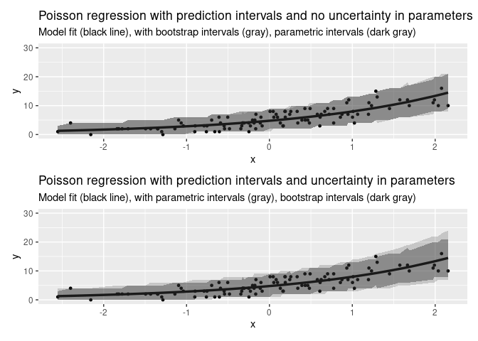

```r
# plots
p1 <- ggplot(dat1, aes(x, y)) +
  geom_point(size = 1) +
  geom_line(aes(y = pred), size = 1.2) +
  geom_ribbon(aes(ymin = lpb, ymax = upb), alpha = 0.2) +
  geom_ribbon(aes(ymin = `lower_pi`, ymax = `upper_pi`), data = dat2[[1]], alpha = 0.4) +
  ggtitle(
    "Poisson regression with prediction intervals and no uncertainty in parameters",
    subtitle = "Model fit (black line), with bootstrap intervals (gray), parametric intervals (dark gray)"
  ) +
  coord_cartesian(ylim=c(0, 30))
p2 <- ggplot(dat1, aes(x, y)) +
  geom_point(size = 1) +
  geom_line(aes(y = pred), size = 1.2) +
  geom_ribbon(aes(ymin = lpb, ymax = upb), alpha = 0.4) +
  geom_ribbon(aes(ymin = `lower_pi`, ymax = `upper_pi`), data = dat3[[1]], alpha = 0.2) +
  ggtitle(
    "Poisson regression with prediction intervals and uncertainty in parameters",
    subtitle = "Model fit (black line), with parametric intervals (gray), bootstrap intervals (dark gray)"
  ) +
  coord_cartesian(ylim=c(0, 30))

p1 / p2
```

## Example 2 - Quassipoisson

```r
# generate data
x <- runif(n = 100, min = 0, max = 2)
mu <- exp(1 + x)
y <- rnegbin(n = 100, mu = mu, theta = mu/(5 - 1))
dat <- data.frame(x = x, y = y)
fit <- glm(y ~ x, family = quasipoisson(link = "log"))

# use ciTools to add prediction interval
dat1 <- add_pi(dat, fit, names = c("lpb", "upb"), alpha = 0.1, nsims = 20000)
head(dat1)
```

```
#>           x y     pred lpb upb
#> 1 1.1373043 2 7.322380   1  18
#> 2 1.3481487 7 9.496419   2  20
#> 3 0.4928128 1 3.307697   0  10
#> 4 0.5307645 3 3.466163   0  10
#> 5 0.7430577 4 4.503316   0  11
#> 6 1.3176464 6 9.145886   2  20
```

```r
# add intervals with trending (no uncertainty in parameters)
quasipoisson_model <- glm_model(y ~ x, family = quasipoisson(link = "log"))
fitted_model <- fit(quasipoisson_model, dat)
dat2 <- predict(fitted_model, simulate_pi = FALSE,  uncertain = FALSE, alpha = 0.1)
dat2 <- get_result(dat2)
head(dat2[[1]])
```

```
#> <trending_prediction> 6 x 7
#>       y     x estimate lower_ci upper_ci lower_pi upper_pi
#>   <int> <dbl>    <dbl>    <dbl>    <dbl>    <dbl>    <dbl>
#> 1     2 1.14      7.32     6.48     8.27        1       17
#> 2     7 1.35      9.50     8.51    10.6         2       20
#> 3     1 0.493     3.31     2.63     4.16        0       10
#> 4     3 0.531     3.47     2.78     4.32        0       10
#> 5     4 0.743     4.50     3.76     5.39        0       12
#> 6     6 1.32      9.15     8.19    10.2         2       20
```

```r
# add intervals with trending (uncertainty in parameters)
dat3 <- predict(fitted_model, simulate_pi = FALSE, alpha = 0.1)
dat3 <- get_result(dat3)
head(dat3[[1]])
```

```
#> <trending_prediction> 6 x 7
#>       y     x estimate lower_ci upper_ci lower_pi upper_pi
#>   <int> <dbl>    <dbl>    <dbl>    <dbl>    <dbl>    <dbl>
#> 1     2 1.14      7.32     6.48     8.27        1       18
#> 2     7 1.35      9.50     8.51    10.6         2       22
#> 3     1 0.493     3.31     2.63     4.16        0       12
#> 4     3 0.531     3.47     2.78     4.32        0       12
#> 5     4 0.743     4.50     3.76     5.39        0       14
#> 6     6 1.32      9.15     8.19    10.2         1       21
```

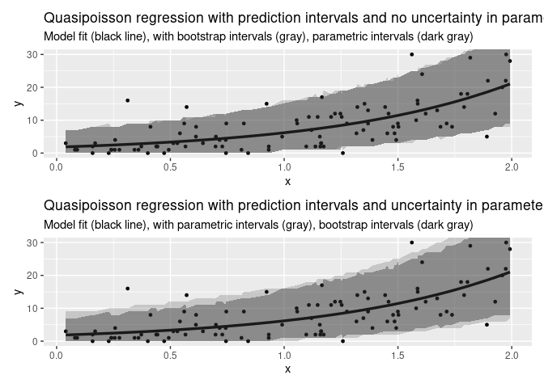

```r
# plots
p3 <- ggplot(dat1, aes(x, y)) +
  geom_point(size = 1) +
  geom_line(aes(y = pred), size = 1.2) +
  geom_ribbon(aes(ymin = lpb, ymax = upb), alpha = 0.2) +
  geom_ribbon(aes(ymin = `lower_pi`, ymax = `upper_pi`), data = dat2[[1]], alpha = 0.4) +
  ggtitle(
    "Quasipoisson regression with prediction intervals and no uncertainty in parameters",
    subtitle = "Model fit (black line), with bootstrap intervals (gray), parametric intervals (dark gray)"
  ) +
  coord_cartesian(ylim=c(0, 30))

p4 <- ggplot(dat1, aes(x, y)) +
  geom_point(size = 1) +
  geom_line(aes(y = pred), size = 1.2) +
  geom_ribbon(aes(ymin = lpb, ymax = upb), alpha = 0.4) +
  geom_ribbon(aes(ymin = `lower_pi`, ymax = `upper_pi`), data = dat3[[1]], alpha = 0.2) +
  ggtitle(
    "Quasipoisson regression with prediction intervals and uncertainty in parameters",
    subtitle = "Model fit (black line), with parametric intervals (gray), bootstrap intervals (dark gray)"
  ) +
  coord_cartesian(ylim=c(0, 30))

p3 / p4
```